Note

Go to the end to download the full example code or to run this example in your browser via JupyterLite or Binder.

# Visualizations with Display Objects

In this example, we will construct display objects, `ConfusionMatrixDisplay`, `RocCurveDisplay`, and `PrecisionRecallDisplay` directly from their respective metrics. This is an alternative to using their corresponding plot functions when a model’s predictions are already computed or expensive to compute. Note that this is advanced usage, and in general we recommend using their respective plot functions.

```
# Authors: The scikit-learn developers
# SPDX-License-Identifier: BSD-3-Clause
```

## Load Data and train model

For this example, we load a blood transfusion service center data set from [OpenML](https://www.openml.org/d/1464). This is a binary classification problem where the target is whether an individual donated blood. Then the data is split into a train and test dataset and a logistic regression is fitted with the train dataset.

```
from sklearn.datasets import fetch_openml
from sklearn.linear_model import LogisticRegression
from sklearn.model_selection import train_test_split
from sklearn.pipeline import make_pipeline
from sklearn.preprocessing import StandardScaler

X, y = fetch_openml(data_id=1464, return_X_y=True)
X_train, X_test, y_train, y_test = train_test_split(X, y, stratify=y)

clf = make_pipeline(StandardScaler(), LogisticRegression(random_state=0))
clf.fit(X_train, y_train)
```

```
Pipeline(steps=[('standardscaler', StandardScaler()),
                ('logisticregression', LogisticRegression(random_state=0))])
```

### Create `ConfusionMatrixDisplay`

With the fitted model, we compute the predictions of the model on the test dataset. These predictions are used to compute the confusion matrix which is plotted with the `ConfusionMatrixDisplay`

```
from sklearn.metrics import ConfusionMatrixDisplay, confusion_matrix

y_pred = clf.predict(X_test)
cm = confusion_matrix(y_test, y_pred)

cm_display = ConfusionMatrixDisplay(cm).plot()
```

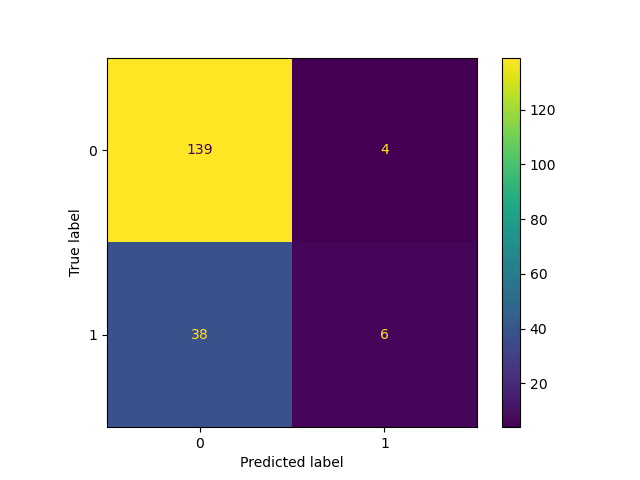

### Create `RocCurveDisplay`

The roc curve requires either the probabilities or the non-thresholded decision values from the estimator. Since the logistic regression provides a decision function, we will use it to plot the roc curve:

```
from sklearn.metrics import RocCurveDisplay, roc_curve

y_score = clf.decision_function(X_test)

fpr, tpr, _ = roc_curve(y_test, y_score, pos_label=clf.classes_[1])
roc_display = RocCurveDisplay(fpr=fpr, tpr=tpr).plot()
```

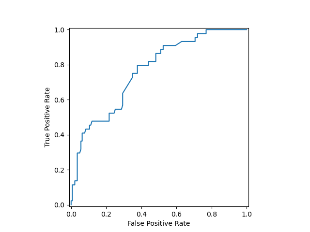

### Create `PrecisionRecallDisplay`

Similarly, the precision recall curve can be plotted using `y_score` from the prevision sections.

```
from sklearn.metrics import PrecisionRecallDisplay, precision_recall_curve

prec, recall, _ = precision_recall_curve(y_test, y_score, pos_label=clf.classes_[1])
pr_display = PrecisionRecallDisplay(precision=prec, recall=recall).plot()
```

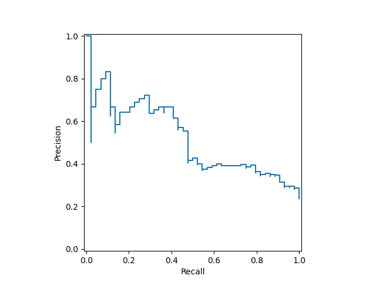

### Combining the display objects into a single plot

The display objects store the computed values that were passed as arguments. This allows for the visualizations to be easily combined using matplotlib’s API. In the following example, we place the displays next to each other in a row.

```
import matplotlib.pyplot as plt

fig, (ax1, ax2) = plt.subplots(1, 2, figsize=(12, 8))

roc_display.plot(ax=ax1)
pr_display.plot(ax=ax2)
plt.show()
```

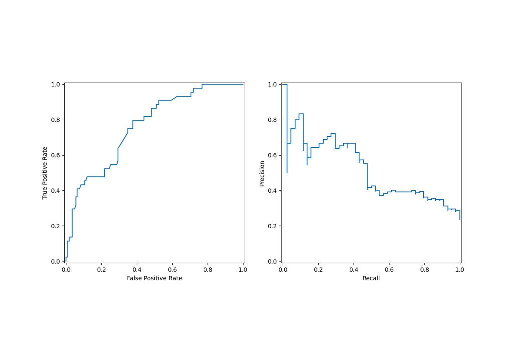

**Total running time of the script:** (0 minutes 0.283 seconds)

[figure not shown]

[`Download Jupyter notebook: plot_display_object_visualization.ipynb`](https://scikit-learn.org/1.9/_downloads/67dd3ba8fc7589bc10a0d9191f17ab66/plot_display_object_visualization.ipynb)

[`Download Python source code: plot_display_object_visualization.py`](https://scikit-learn.org/1.9/_downloads/ff5c36c46d02d3f6e6acbc298cf36708/plot_display_object_visualization.py)

[`Download zipped: plot_display_object_visualization.zip`](https://scikit-learn.org/1.9/_downloads/4796ad47eaaf6dee0097a73a3c92ca19/plot_display_object_visualization.zip)

#### Related examples

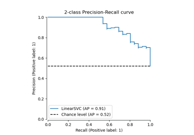

Precision-Recall

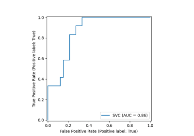

ROC Curve with Visualization API

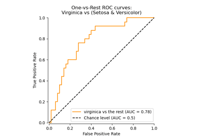

Multiclass Receiver Operating Characteristic (ROC)

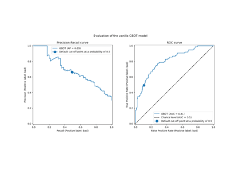

Post-tuning the decision threshold for cost-sensitive learning

© 2007–2026 The scikit-learn developers  
Licensed under the 3-clause BSD License.  
https://scikit-learn.org/1.9/auto_examples/miscellaneous/plot_display_object_visualization.html